# 2021: Inflation Spike Components

Ian Bogley

2023-12-30

## Background

In the early 2020’s, one of the defining issues of debate surrounding the American economy was that of inflation. For 13 years, inflation had remained low despite rock-bottom interest rates. In March of 2021, however, it came roaring back with a vengeance, causing pain for consumers throughout the economy. The purpose of this blog will be to deconstruct the spike in inflation, looking at the goods and services which contributed to this inflation and quantifying their contributions relative to each other.

[figure not shown]

The Federal Reserve is responsible for adjusting interest rates (Federal Funds Rate) to achieve their dual mandate: price stability and full employment. Interest rates affect these two metrics by making credit more or less available, through making borrowing money more or less expensive. In other words, the interest rate is essentially a marker of the cost of borrowing. In times of high inflation, the fed will raise interest rates to make borrowing more expensive, reducing the flow of credit and money into the economy, which in turn helps to stabilize prices through wages. In times of high unemployment, the fed can reduce interest rates to increase the availability of credit to businesses, allowing them to make more investments and hire more people.

This made it somewhat confusing when the low interest rates from 2008-2020 saw relatively steady prices. Starting in 2021, however, inflation would dramatically spike to almost 9% year-over-year, a watermark not reached since November 1981.

## CPI Component Overview

So what goods and services were responsible for such a dramatic spike? To discuss this question, we have to begin with a basic overview of how the Consumer Price Index (CPI) works, the go-to numbers for general inflation work. For this blog, we will only be using prices in urban settings, as the consumption and variance of prices associated with rural consumers is different than that of urban ones. Also, the urban index accounts for about 88% of the US population.

At the base level, price data is collected for each basket of goods and services in each locality. From there, these are aggregated via their “weights” and “relative importance”. Weights define the average amount of different goods and services consumed in a category. These weights are updated annually beginning in 2022, but before then generally were updated once every two years. Relative importance aggregates between different categories through the portion of overall spending for a given locality. Aggregations work their way up to the national level through relative importance to provide us with the indices that we are working with here.

We will take a look at the behavior of individual components in the headline inflation rate, and compare them using their relative importance. The three categories we will work with are food, energy, and core (everything except food and energy). Food generally accounts for 13-14% of the overall change in prices, energy is 6-7%, and core components are around responsible for around 80%. Food and energy are often separated out because they are known to be more volatile in their short-term prices in comparison to goods and services in the core basket.

## CPI Component Behavior

In 2020, energy prices were actually decreasing. This makes sense, given that much of the U.S. was under strict lockdown to prevent the spread of COVID-19. A logical hypothesis might be that less people were driving, leading to large decrease in the demand for oil and gas. However, in 2021, energy prices spiked massively by 20-40% year-over-year. This makes sense, as much of the country was coming out of lockdown. However, this was followed by dramatic increases in the other two categories as well.

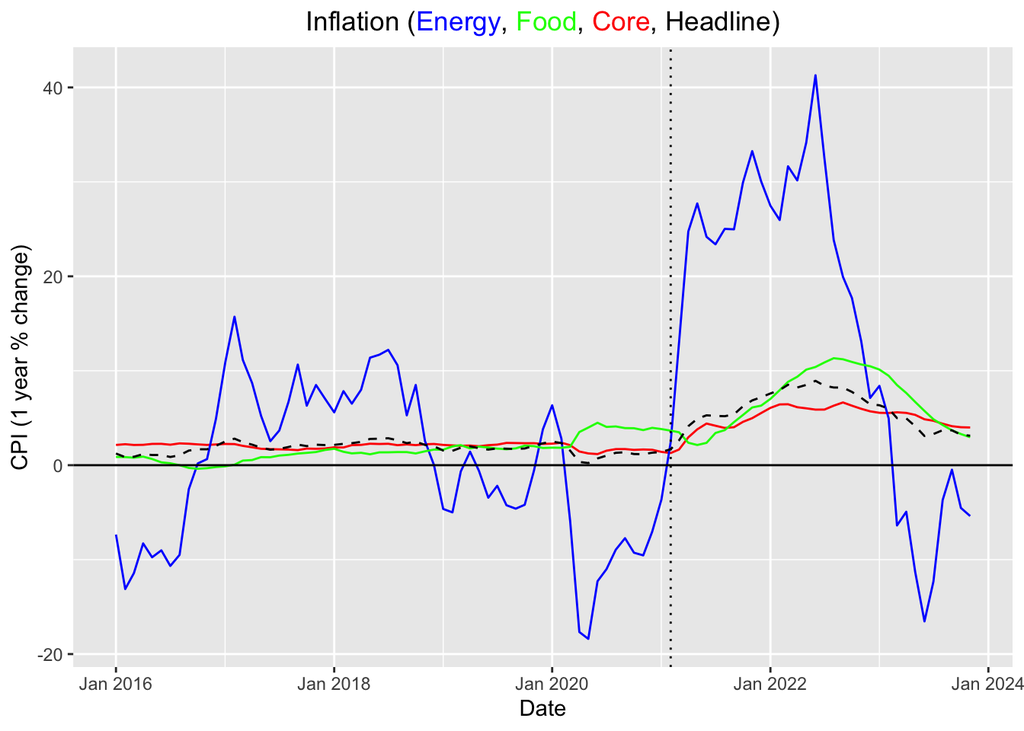

When breaking down the energy sector in more detail, we can see that the majority of the spike came from energy commodities, which comes mostly from motor fuel and other fossil fuel related products. This seems consistent with our previous narrative related to the pandemic: after a full year with severely decreased demand for oil and gas, the resurgence of demand led to a dramatic increase in prices. This perhaps coincided with supply issues as oil and gas suppliers struggled to meet demand.

[figure not shown]

## Analysis, Outlook

However, this brings up the question of how big an influence the energy price shock was in comparison to the inflation from other goods and services. When doing so, we can see a few trends: while the increase in energy prices was real and a source of inflation for the overall headline index, a majority of the inflation in each period came from inflation in the core index. Also, energy prices have served as a deflationary influence on the headline index since March 2023.

Finally, since the inflationary peak in June 2022, inflation has consistently declined, driven by the more volatile indecies while core inflation has remained sticky. Core inflation has been coming down gradually, but I would not expect the inflation rate to reach pre-2021 levels any time soon, as it may take some time for core inflation to work itself out. This of course assumes that the Fed is successful in maintaining expectations of 2% annual inflation into the future.

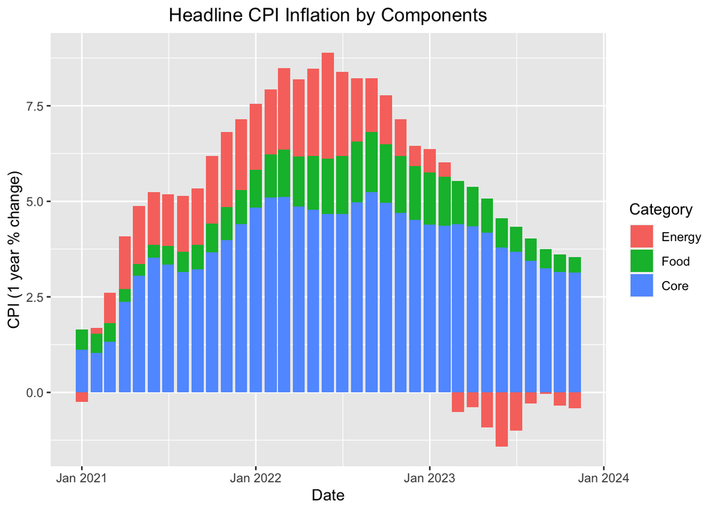

*For QC, I used a similar visual that the White House used to show inflation by components. Check out their blog here: https://www.whitehouse.gov/cea/written-materials/2023/04/27/update-on-housing-inflation-in-cpi/

## Sources

U.S. Bureau of Labor Statistics, Consumer Price Index for All Urban Consumers: All Items in U.S. City Average [CPIAUCSL], retrieved from FRED, Federal Reserve Bank of St. Louis; https://fred.stlouisfed.org/series/CPIAUCSL, December 30, 2023.

Board of Governors of the Federal Reserve System (US), Federal Funds Effective Rate [FEDFUNDS], retrieved from FRED, Federal Reserve Bank of St. Louis; https://fred.stlouisfed.org/series/FEDFUNDS, December 30, 2023.

U.S. Bureau of Labor Statistics, Consumer Price Index for All Urban Consumers: All Items Less Food and Energy in U.S. City Average [CPILFESL], retrieved from FRED, Federal Reserve Bank of St. Louis; https://fred.stlouisfed.org/series/CPILFESL, December 30, 2023.

U.S. Bureau of Labor Statistics, Consumer Price Index for All Urban Consumers: Energy in U.S. City Average [CPIENGSL], retrieved from FRED, Federal Reserve Bank of St. Louis; https://fred.stlouisfed.org/series/CPIENGSL, December 30, 2023.

U.S. Bureau of Labor Statistics, Consumer Price Index for All Urban Consumers: Food in U.S. City Average [CPIUFDSL], retrieved from FRED, Federal Reserve Bank of St. Louis; https://fred.stlouisfed.org/series/CPIUFDSL, December 30, 2023.

U.S. Bureau of Labor Statistics, Consumer Price Index for All Urban Consumers: Energy Commodities in U.S. City Average [CUSR0000SACE], retrieved from FRED, Federal Reserve Bank of St. Louis; https://fred.stlouisfed.org/series/CUSR0000SACE, December 30, 2023.

U.S. Bureau of Labor Statistics, Consumer Price Index for All Urban Consumers: Energy Services in U.S. City Average [CUSR0000SEHF], retrieved from FRED, Federal Reserve Bank of St. Louis; https://fred.stlouisfed.org/series/CUSR0000SEHF, December 30, 2023.

U.S. Bureau of Labor Statistics, Relative Importance Data: December 2022 (2021 weights), December 2021 (2019-2020 weights), December 2020 (2017-2018 weights), December 2019 (2017-2018 weights), https://www.bls.gov/cpi/tables/relative-importance/home.htm, December 30, 2023

U.S. Bureau of Labor Statistics, Handbook of Methods: Consumer Price Index, https://www.bls.gov/opub/hom/cpi/concepts.htm, December 30, 2023